# Capstone Project - Predicting Text

Partha Majumdar

14 November 2014

# INTRODUCTION

The purpose of this project is to develop a text predicting algorithm based on the text provided in 3 files containing English Language Text collected from Blogs, News Articles and Twitter.

This document describes the analysis of the provided data for the purpose of creating the algorithm for predicting text. This document first describes the conduction preliminary analysis of the files in terms of finding number of lines, words, sentences. Then, the document analyses a part of the Twitter file for analysing frequent terms used, word associations and clustering of words.

As the document provides plots of the analysis, the amount of data used for the analysis has been kept small. However, selecting a small set of data from a large data set randomly can be equally as effective for the purpose of reasonably accurate prediction.

# INPUT ANALYSIS

3 Source Files have been provided. They are as follows.

```
## [1] "en_US.blogs.txt"   "en_US.news.txt"    "en_US.twitter.txt"
```

### Analysis of the Files

| fileName | linesPerFile | wordsPerFile | avgWordsPerFile |
| --- | --- | --- | --- |
| en_US.blogs.txt | 899288 | 36886194 | 41.01711 |
| en_US.news.txt | 1010242 | 33535577 | 33.19559 |
| en_US.twitter.txt | 2360148 | 29414810 | 12.46312 |

However, we notice that the number of words in all the 3 files is quite similar though the number of lines of text in Twitter is far more than the number of lines in Blogs and News file. This is expected as there is a limitation on the number of characters that can be used per tweet and there is no such limit when writing Blogs or writing News articles.

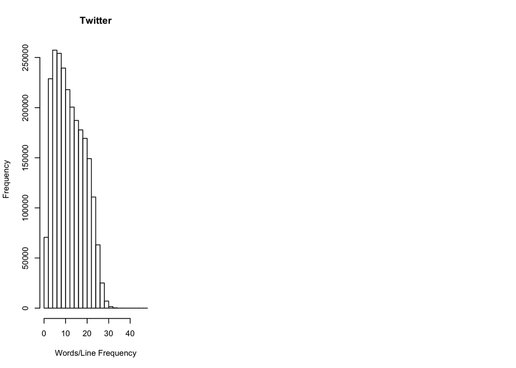

These graphs show that the words per line in Twitter files is fairly regular. Whereas, in Blogs and in News articles, most of the lines contains very few words and a few lines contains a lot of words. **(The graphs for blog and news have been excluded to shorten the size of the file as RPUBS and GUTHUB gives errors)**

### Analysis of the Words

This display below gives an idea of the most frequently and least frequently used words in forming sentences in Blogs, News and Twitter. The frequency distribution of the words is also provided here separately for the Blogs, News and Twitter.

Commonly used words like pronouns, etc. have been removed from the word list.

A separate analysis is performed to see the volume of profanity words (swear words) used in the Blogs, News and Twitter (The profanity word list is obtained from the Internet and may not be a complete list).

After taking the initial measures, we clean the documents. The following steps were implemented for cleaning the documents.

1. Remove all symbols.
2. Replace all digits.

#### 1. Blog

The Top *10* words (most frequently occuring) in the file “*en_US.blogs.txt*” is provided below.

```
##    WORD    FREQ
## 1  about 114832
## 2  out   108098
## 3  up    105541
## 4  just   99524
## 5  like   97912
## 6  more   92065
## 7  time   87438
## 8  get    70480
## 9  know   59505
## 10 now    58780
```

*The Top 10 words occur 2.42 percent time in the document.*

**The number of use of profanity words in Blogs is 20157 times.**

The frequency distribution of the words used in Blog is given below (after removing commonly used words and after profanity treatment).

The mean of the word frequency is 42.0271856.

The median of the word frequency is 1.

**(The graphs for blog and news have been excluded to shorten the size of the file as RPUBS and GUTHUB gives errors)**

**The number of words removed during the Blog document cleaning process is 21690.**

#### 2. News

The Top *10* words (most frequently occuring) in the file “*en_US.news.txt*” is provided below.

```
##    WORD    FREQ
## 1  said  250326
## 2  about  89527
## 3  more   87913
## 4  up     72030
## 5  out    71482
## 6  new    70189
## 7  after  62416
## 8  year   57320
## 9  just   52981
## 10 first  52542
```

The Top **10** words occur 2.58 percent time in the document.

**The number of use of profanity words in News is 7162 times.**

The frequency distribution of the words used in News is given below (after removing commonly used words and after profanity treatment).

The mean of the word frequency is 57.9986147.

The median of the word frequency is 2.

**(The graphs for blog and news have been excluded to shorten the size of the file as RPUBS and GUTHUB gives errors)**

**The number of words removed during the News document cleaning process is 7967.**

#### 3. Twitter

The Top *10* words (most frequently occuring) in the file “*en_US.twitter.txt*” is provided below.

```
##    WORD    FREQ
## 1  im    157871
## 2  just  149580
## 3  like  121279
## 4  out   114020
## 5  up    112830
## 6  get   111901
## 7  love  105430
## 8  good   99549
## 9  about  90929
## 10 day    89815
```

*The Top 10 words occur 3.92 percent time in the document.*

**The number of use of profanity words in Twitter is 85831 times.**

The frequency distribution of the words used in Twitter is given below (after removing commonly used words and after profanity treatment).

The mean of the word frequency is 35.2041203.

The median of the word frequency is 1.

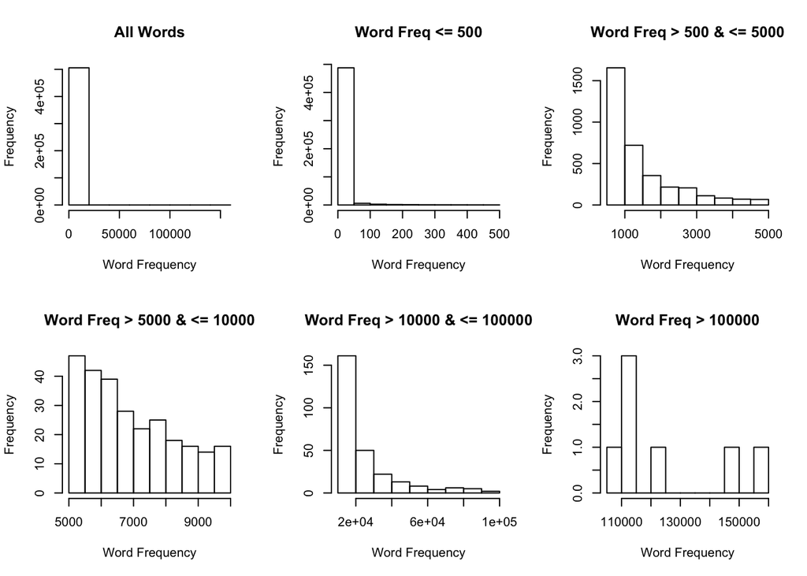

**The number of words removed during the Twitter document cleaning process is 88832.**

### Analysis of the Sentences

Sentence analysis is conducted on 100,000 lines of text in each of the files.

1. Blog = 209276
2. News = 175972
3. Twitter = 91381

**Word associations** in Twitter file is provided below. 1000 sentences from the Twitter file is used for this analysis.

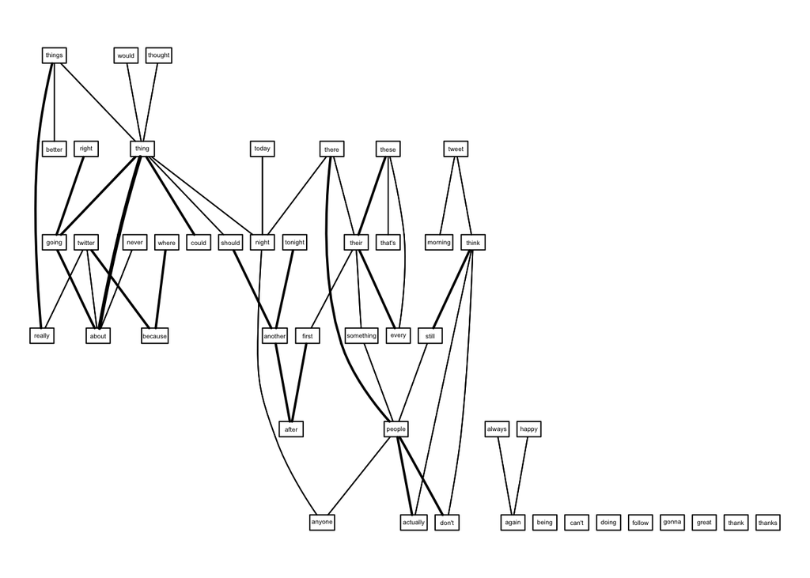

**Clustering analysis** is provided below.

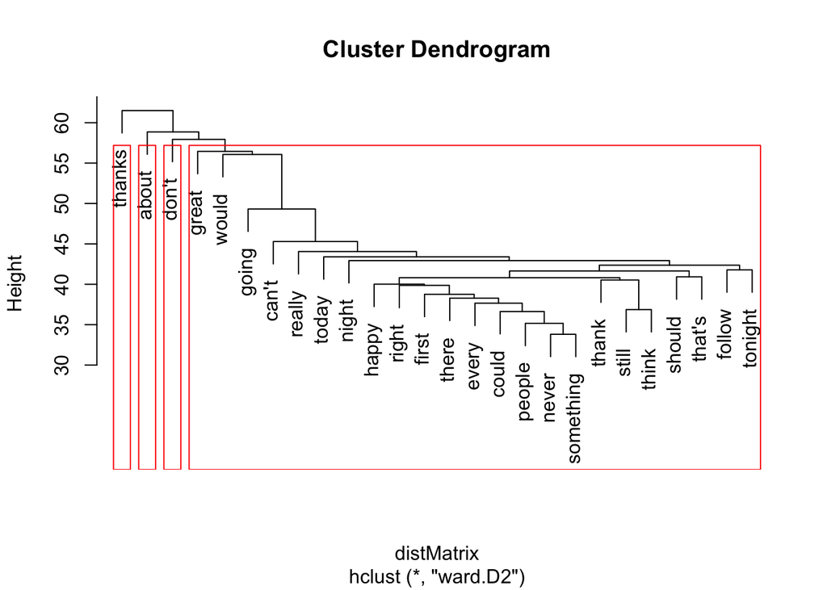